# Homework 3: Exponential & Gamma via Poisson Processes and Monte Carlo

10/22/2025

### Overview & Motivation

Suppose web requests (or API calls) arrive randomly to a server. When arrivals are independent and have a constant average rate over time, a classic model is the Poisson process with rate $\lambda$ (arrivals per unit time). Two fundamental random variables arise:

- Inter-arrival time ($X$): time from one request to the next. If arrivals follow a Poisson process, then $X$ follows an Exponential distribution, $X \sim \mathrm{Exp}(\lambda)$.
- Waiting time to the $k$-th arrival ($T_k$): sum of $k$ inter-arrival times, which yields $T_k \sim \mathrm{Gamma}(k, \, \lambda)$ (also called Erlang when $k$ is an integer).

These distributions show up in network traffic (packet/request timing), call centers, radiation detection, reliability (time-to-failure) and queueing models. The Exponential’s memoryless property and the Gamma’s “sum of exponentials” structure are the key features you’ll explore—both analytically and via Monte Carlo simulation.

> **Goal of this HW.** Build intuition for Exponential & Gamma from first principles, verify properties via **Monte Carlo**, and connect to **Poisson counts**.

#### 1) From Poisson counts to the Exponential waiting time

> In a Poisson process with rate $\lambda$, “no arrivals in $(0,x]$” has probability $e^{-\lambda x}$. The **waiting time** $X$ to the next arrival then satisfies $P(X>x)=e^{-\lambda x}$.

Imagine time flowing continuously, and “events” (like web requests, calls, or radioactive decays) arriving at random times according to a Poisson process with rate $\lambda$:

- $\lambda$ = average number of arrivals per unit time (e.g., 2 arrivals per minute).

The key assumptions of a Poisson process:

- Events occur independently, and
- The number of arrivals in any time interval of length $t$ follows $N(t)\sim \mathrm{Poisson}(\lambda t)$, meaning that $\Pr(N(t)=k)=\frac{e^{-\lambda t}(\lambda t)^k}{k!},\ k=0,1,2,\ldots$.

Define the **waiting time** random variable $X$ as the time to first arrival. Then, the event $\{X>x\}$ is exactly the event that no arrivals have occurred in $(0,x]$, i.e.
$$\{X>x\}=\{N(x)=0\}.$$
Hence, using the Poisson probability for zero counts,
$$\Pr(X>x)=\Pr\{N(x)=0\}=e^{-\lambda x},\qquad x\ge 0.$$

From this definition, it should be clear that the cdf of $X$ is $F_X(x) = 1-e^{-\lambda x}$ and consequently, the probability density function is $f_X(x) = \lambda e^{-\lambda x}$.

That is, $X \sim Exp(\lambda)$. Using integration by parts, we can easily show that $E[X]=1/\lambda$ and $\mathrm{Var}(X)=1/\lambda^2$.

**Memoryless Property of the Exponential Distribution** Let $X \sim Exp(\lambda)$ be a random variable representing the waiting time until the next event in a Poisson process with rate $\lambda>0$. Then, for any $s,t>0$,
$$P(X>s+t \mid X>s)=P(X>t)$$
This means that the probability of waiting more than $t$ additional time units does not depend on how long you have already waited ($s$). In other words, the exponential distribution has no memory of the past.The exponential distribution is the only continuous distribution that satisfies this memoryless property.

**Exercise 1.** Prove the memoryless property of the Expenential distribution (Hint: use the definition of conditional probability).

#### 2) Monte Carlo: verifying Exponential properties

Suppose web requests arrive to a server according to a Poisson process with rate $\lambda=0.5$ requests per minute (so the mean inter-arrival time is 2 minutes). Let $X$ denote an inter-arrival time.

**Exercise 2** Generate $n=100$ samples for web-requests inter-arrival times (Hint: use `rexp`). Compute the empirical mean and variance and compare them to the theoretical values. Repeat the process for $n=100,000$. Briefly explain what you observe.

**Solution** For an exponential distribution the theoretical mean and variance is described below.

Theoretical mean E[$X$] = 1/$\lambda$  
Theoretical variance V[$X$] = 1/($\lambda$)^2

Observations: When the sample size increases to 100K we see the empirical mean and variance get closer to their theoretical values.

```r
# number <- 100
# # Define the rate param.
# rate <- .5
# # Define the theoretical mean and variance
# theoretical_mean <- 1/rate
# theoretical_var <- 1/(rate^2)
#
# # rexp(number, rate = rate)
#
# paste("Theoretical mean is ", theoretical_mean)
# paste("Theoretical variance is ", theoretical_var)
# print("-----")
#
#
# # Create an exponential vector
# sample_100_exponential <- rexp(number, rate = rate)
#
#
# # Set values for the sample size 100 mean and variance
# empirical_100_mean <- mean(sample_100_exponential)
# empirical_100_var <- var(sample_100_exponential)
# # Print this out
# paste("Sample size 100, Mean: ", empirical_100_mean)
# paste("Sample size 100, Variance ", empirical_100_var)
#
# # do some calculations
# empirical_mean_100_diff <- (theoretical_mean - empirical_100_mean) / 100
# empirical_var_100_diff <- (theoretical_var - empirical_100_var) / 100
# paste("Size 100 mean difference: ", empirical_mean_100_diff)
# paste("Size 100 variance difference: ", empirical_var_100_diff)
#
#
# # Scale this up to 100K
# big_number <- 100000
# big_number_exponential <- rexp(big_number, rate = rate)
#
# # Set values for the new larger sample size (mean and variance)
# empirical_hundred_k_mean <- mean(big_number_exponential)
# empirical_hundred_k_var <- var(big_number_exponential)
#
# paste("Sample size 100K, Mean ", empirical_hundred_k_mean)
# paste("Sample size 100K, Variance ", empirical_hundred_k_var)
#
# empirical_hundred_k_mean_difference <- (theoretical_mean - empirical_hundred_k_mean) / 100
# empirical_hundred_k_var_difference <- (theoretical_var - empirical_hundred_k_var) / 100
# paste("Size 100K mean difference: ", empirical_hundred_k_mean_difference)
# paste("Size 100K variance differnece: ", empirical_hundred_k_var_difference)
# # mean(rexp(big_number, rate = rate))
# # mean(rexp(big_number, rate = rate))


###########################################################################
## By un-commenting the following lines, making bigger_number set to 1M, even though it takes a little more compute time, we see that the mean and variance falls within 1000th of the actual value every run.
# bigger_number <- 100000000
# paste("Sample size 100000000, Mean ", mean(rexp(bigger_number, rate = rate)))
# paste("Sample size 100000000, Variance ", var(rexp(bigger_number, rate = rate)))


###########################################################################
# Define the rate parameter (lambda)
lambda <- 0.5
# Define the theoretical mean and variance
theoretical_mean <- 1 / lambda
theoretical_variance <- 1 / (lambda^2)

# Function to perform the simulation and comparison
simulate_and_compare <- function(n_samples, lambda_rate) {
  # Generate n samples for inter-arrival times
  samples <- rexp(n_samples, rate = lambda_rate)

  # Compute the empirical mean and variance
  empirical_mean <- mean(samples)
  empirical_variance <- var(samples)

  # Print results
  cat(sprintf("Results for n = %d samples:\n", n_samples))
  cat(sprintf("  Empirical Mean:    %.4f\n", empirical_mean))
  cat(sprintf("  Theoretical Mean:  %.4f\n", theoretical_mean))
  cat(sprintf("  Difference (Mean): %.4f\n", abs(empirical_mean - theoretical_mean)))
  cat(sprintf("  Empirical Variance:    %.4f\n", empirical_variance))
  cat(sprintf("  Theoretical Variance:  %.4f\n", theoretical_variance))
  cat(sprintf("  Difference (Variance): %.4f\n\n", abs(empirical_variance - theoretical_variance)))
}

# Run for n = 100
simulate_and_compare(100, lambda)
```

```
## Results for n = 100 samples:
##   Empirical Mean:    2.0998
##   Theoretical Mean:  2.0000
##   Difference (Mean): 0.0998
##   Empirical Variance:    5.6434
##   Theoretical Variance:  4.0000
##   Difference (Variance): 1.6434
```

```r
# Run for n = 100,000
simulate_and_compare(100000, lambda)
```

```
## Results for n = 100000 samples:
##   Empirical Mean:    1.9986
##   Theoretical Mean:  2.0000
##   Difference (Mean): 0.0014
##   Empirical Variance:    3.9721
##   Theoretical Variance:  4.0000
##   Difference (Variance): 0.0279
```

```r
###########################################################################
```

**Exercise 3** Plot a histogram of the generated data for $n=100$ and $n=100,000$ and overlay the theoretical pdf. Briefly describe what you observe.

Observation: We can see that when n = 100 the histogram is jagged and only provides a rough estament of the theoretical measurement of the exponential PDF. The sample size of n = 100000 approximates the theoretical measurement much better and the plot is much smoother.

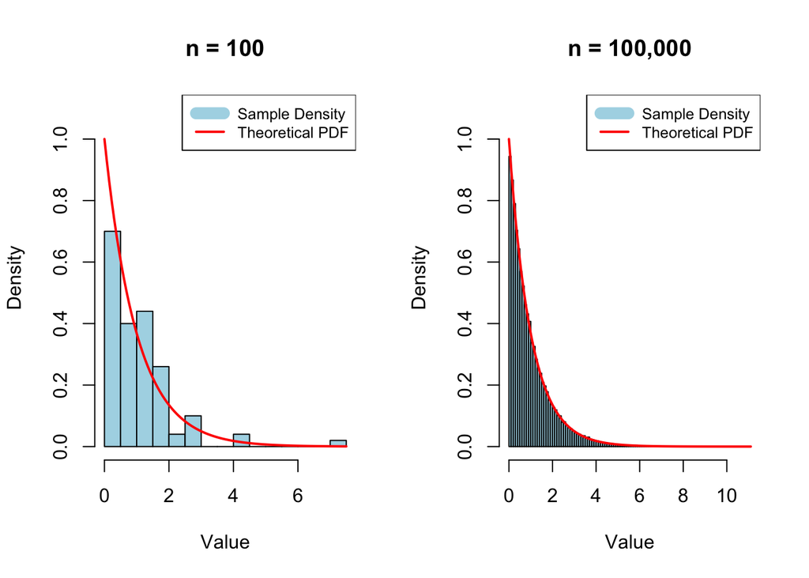

```r
# Set a seed for reproducibility
set.seed(123)

# Define the rate parameter (lambda)
lambda <- 1

# Generate data for n = 100
n_100 <- 100
data_100 <- rexp(n_100, rate = lambda)

# Generate data for n = 100,000
n_100k <- 100000
data_100k <- rexp(n_100k, rate = lambda)

# Set up the plotting area to show two plots side-by-side
par(mfrow = c(1, 2))

# Plot for n = 100
hist(data_100, freq = FALSE, breaks = 20, col = "lightblue",
     main = "n = 100", xlab = "Value", ylab = "Density",
     ylim = c(0, lambda * 1.1)) # Adjust ylim for consistency

curve(dexp(x, rate = lambda), col = "red", lwd = 2, add = TRUE)
legend("topright", legend = c("Sample Density", "Theoretical PDF"),
       col = c("lightblue", "red"), lty = c(1, 1), lwd = c(10, 2), cex = 0.8)

# Plot for n = 100,000
hist(data_100k, freq = FALSE, breaks = 100, col = "lightblue",
     main = "n = 100,000", xlab = "Value", ylab = "Density",
     ylim = c(0, lambda * 1.1)) # Adjust ylim for consistency

curve(dexp(x, rate = lambda), col = "red", lwd = 2, add = TRUE)
legend("topright", legend = c("Sample Density", "Theoretical PDF"),
       col = c("lightblue", "red"), lty = c(1, 1), lwd = c(10, 2), cex = 0.8)
```

```r
# Reset plotting area to default
par(mfrow = c(1, 1))




####################################################################
# h <- hist(sample_100_exponential,
#      probability=TRUE,
#      breaks=20,
#      col="darkmagenta",
#      main="Histogram of exponential sample size 100")
# plot(h, col="darkmagenta")
# xlines <- seq(min(h$breaks),max(h$breaks),length.out=100)
# lines(x = xlines, y = dexp(xlines, rate = rate))
#
# hb <- hist(big_number_exponential,
#      col="darkmagenta",
#      breaks=100,
#      main="Histogram of exponential sample size 100K")
# plot(hb, col="darkmagenta")
# xlines <- seq(min(hb$breaks),max(hb$breaks),length.out=100)
# lines(x = xlines, y = dexp(xlines, rate = rate))
####################################################################


# x <- sample_100_exponential #crate the sample
# h2 <- hist(x, plot=FALSE) #generate histogram
# plot(h2, col="grey") #plot the histogram of sample_100_exponential
# xlines <-seq(min(h2$breaks),max(h2$breaks),length.out=100) #seq of x for pdf
# lines(x = xlines,y=dexp(xlines,2,1) *length(x)*diff(h2$breaks)[1])
# # # # #
# x <- big_number_exponential #create the sample
# h3 <- hist(x, plot=FALSE) #generate histogram
# plot(h3, col="darkmagenta") #plot the histogram of big_number_exponential
# xlines <-seq(min(h3$breaks),max(h3$breaks),length.out=100) #seq of x for pdf
# lines(x = xlines,y=dexp(xlines,2,1) *length(x)*diff(h3$breaks)[1])
```

**Exercise 4** (Monte Carlo memoryless check). Use your simulated exponential sample with $n=100,000$ from Exercise 2 to empirically verify the memoryless property. Estimate $P(X>s+t\mid X>s)$ and $P(X>t)$ for $s=3$ and $t=4$. Report both estimates and compare them. Discuss Monte Carlo error if numbers are close but not identical.

```r
# Estimate P(X > s+t | X > s)
s <- 3
t <- 4
conditional_prob_estimate <- sum(data_100k > s+t) / sum(data_100k > s)

# Estimate P(X > t)
unconditional_prob_estimate <- sum(data_100k > t) / n_100k

# Print the results
print(paste("Estimated P(X > 7 | X > 3):", conditional_prob_estimate))
```

```
## [1] "Estimated P(X > 7 | X > 3): 0.0169796244506592"
```

```r
print(paste("Estimated P(X > 4):", unconditional_prob_estimate))
```

```
## [1] "Estimated P(X > 4): 0.01791"
```

#### 3) Gamma as a sum of exponentials

In a Poisson process with rate $\lambda$, the waiting time between consecutive events is modeled by an exponential random variable $X_i \sim \mathrm{Exp}(\lambda)$. If we let
$$T_k = X_1 + X_2 + \cdots + X_k,$$
then $T_k$ represents the total waiting time until the $k$-th event occurs.

**Exercise 5** (Simulation) For $\lambda=0.5$ and $k=5$, generate two samples of size $n=10,000$:

1. Directly from the gamma distribution (Hint: use `rgamma`).
2. As the sum of $k$ exponentials.

Compute the sample means and variances of both samples and compare them to the theoretical values. Plot histograms of the two sample (ideally over the same axis) and compare them. Briefly discuss what you observe.

**Solution**

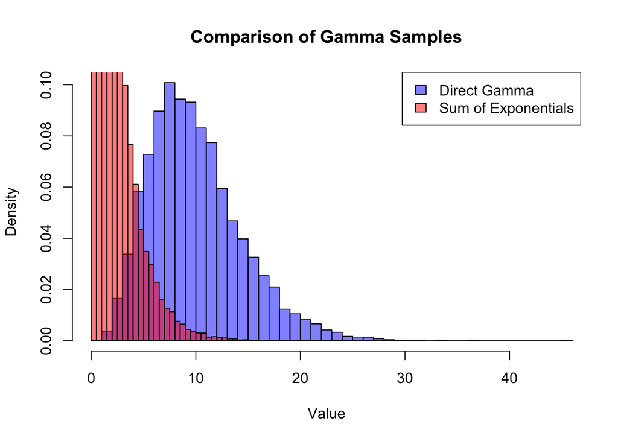

```r
l <- .5
k <- 5
n_10K <- 10000


# Theoretical values for Gamma distribution
theoretical_mean <- k / l
theoretical_variance <- k / (l^2)

# Create a sample directly using rgamma
direct_gamma_sample <- rgamma(n_10K, shape = k, rate = l)

# Create a sample as the sum of k exponential
exponential_sums <- matrix(rexp(n_10K * k, rate = l))
sample_sum_of_exponentials <- rowSums(exponential_sums)


# View the data
# head(direct_gamma_sample)
# head(sample_sum_of_exponentials)

# Compute mean and variance of both samples
mean_direct_gamma_sample <- mean(direct_gamma_sample)
variance_direct_gamma_sample <- var(direct_gamma_sample)


mean_sample_sum_of_exponentials <- mean(sample_sum_of_exponentials)
var_sample_sum_of_exponentials <- var(sample_sum_of_exponentials)



# Plot histograms
hist(direct_gamma_sample, breaks = 50, col = rgb(0, 0, 1, 0.5),
     main = "Comparison of Gamma Samples", xlab = "Value",
     freq = FALSE, xlim = range(c(direct_gamma_sample, sample_sum_of_exponentials)))
hist(sample_sum_of_exponentials, breaks = 50, col = rgb(1, 0, 0, 0.5), add = TRUE, freq = FALSE)
legend("topright", legend = c("Direct Gamma", "Sum of Exponentials"),
       fill = c(rgb(0, 0, 1, 0.5), rgb(1, 0, 0, 0.5)))
```